# Machine Learning tools

## Development Environments and Libraries

- **Jupyter Notebook**: An open-source web application that allows you to create and share documents containing live code, equations, visualizations, and narrative text.
- **Google Colab**: A free Jupyter notebook environment that requires no setup and runs entirely in the cloud, with free access to computing resources including GPUs.
- **TensorFlow**: An open-source platform for machine learning developed by Google, offering comprehensive tools, libraries, and community resources. PyTorch: An open-source machine learning library developed by Facebook, known for its flexibility and dynamic computational graph.

## Data Processing and Analysis

- **Pandas**: A fast, powerful, flexible, and easy-to-use open-source data analysis and manipulation tool, built on top of the Python programming language.
- **NumPy**: A fundamental package for scientific computing with Python, providing support for large, multi-dimensional arrays and matrices, along with a collection of mathematical functions to operate on these arrays.
- **Scikit-learn**: An open-source machine learning library for Python, providing simple and efficient tools for data mining and data analysis.

## Visualization Tools

- **Matplotlib**: A comprehensive library for creating static, animated, and interactive visualizations in Python.
- **Seaborn**: A Python data visualization library based on matplotlib that provides a high-level interface for drawing attractive statistical graphics.

## Matplotlib Demo

Note that you must have installed matplot lib: [Installation @matplotlib](https://matplotlib.org/stable/users/installing/index.html)

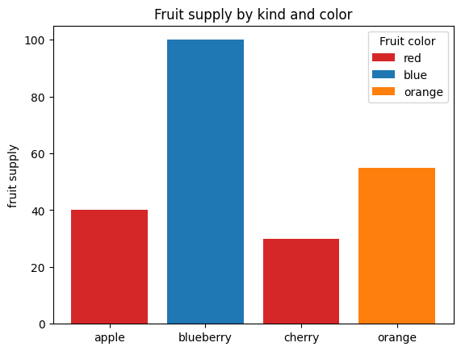

```python
import matplotlib.pyplot as plt

fig, ax = plt.subplots()

fruits = ['apple', 'blueberry', 'cherry', 'orange']
counts = [40, 100, 30, 55]
bar_labels = ['red', 'blue', '_red', 'orange']
bar_colors = ['tab:red', 'tab:blue', 'tab:red', 'tab:orange']

ax.bar(fruits, counts, label=bar_labels, color=bar_colors)

ax.set_ylabel('fruit supply')
ax.set_title('Fruit supply by kind and color')
ax.legend(title='Fruit color')

plt.show()
```